# **STAT I512, Honglang Wang (hlwang)**

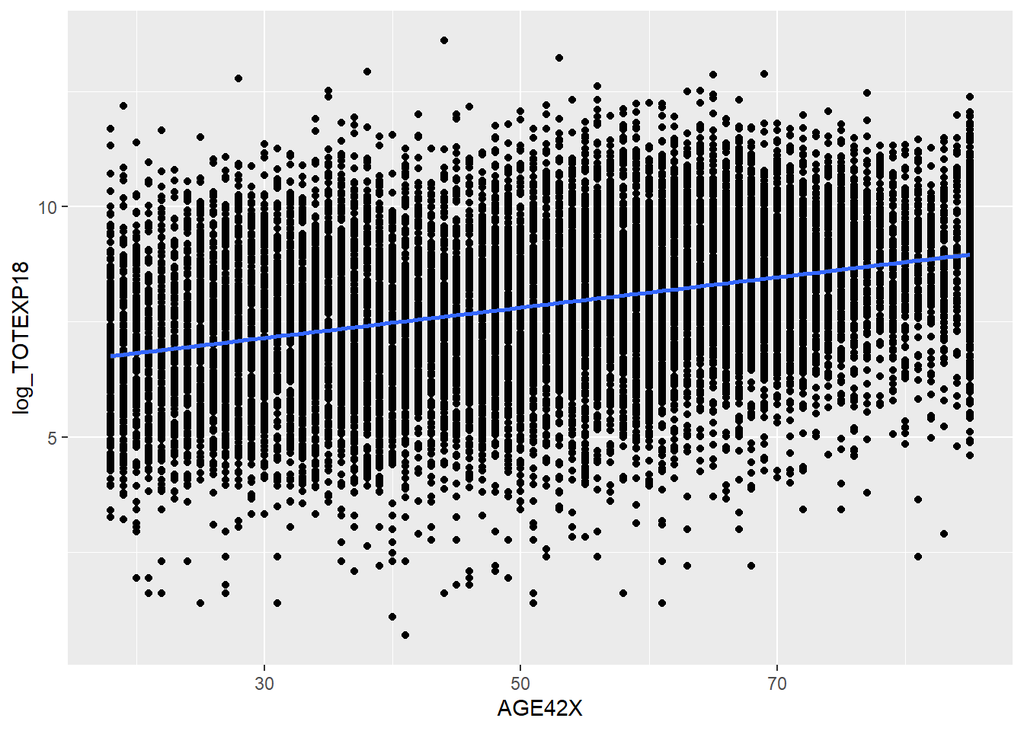

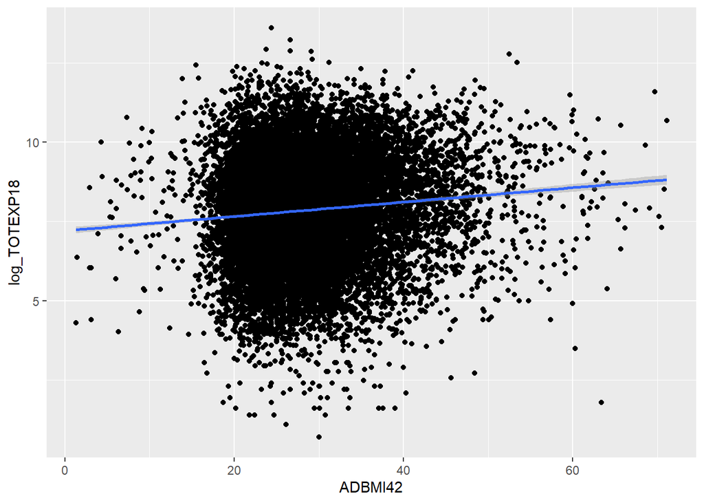

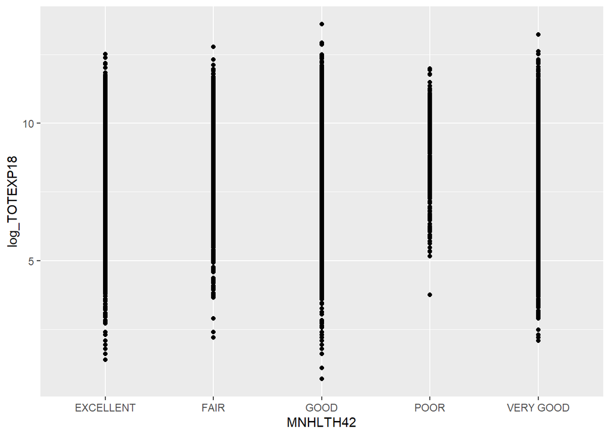

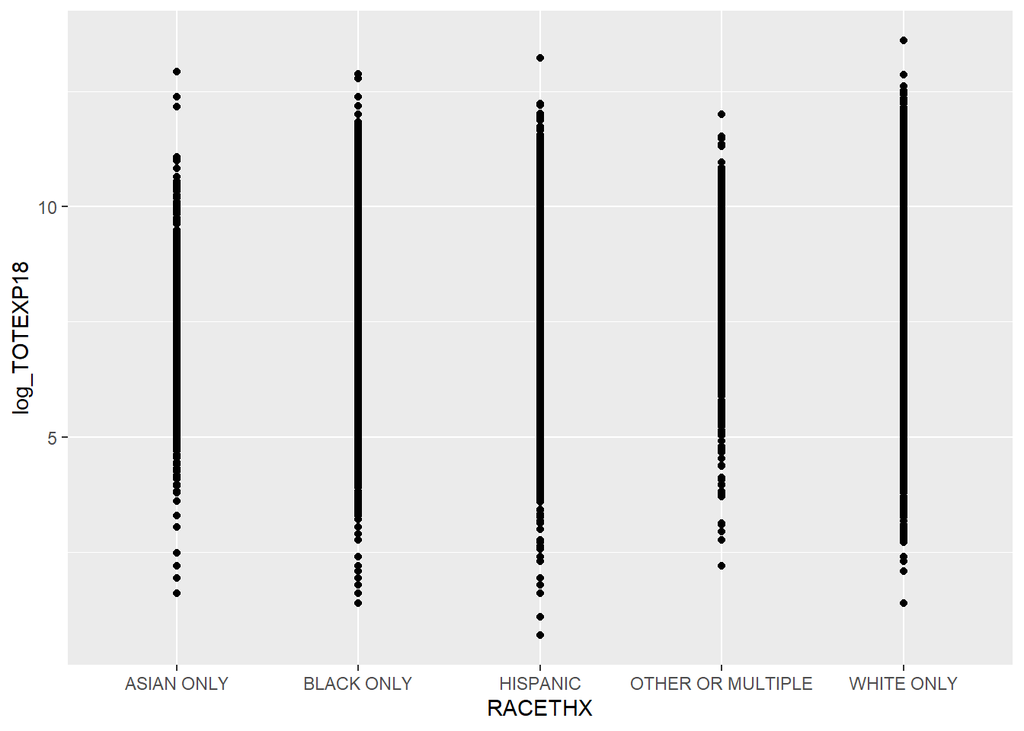

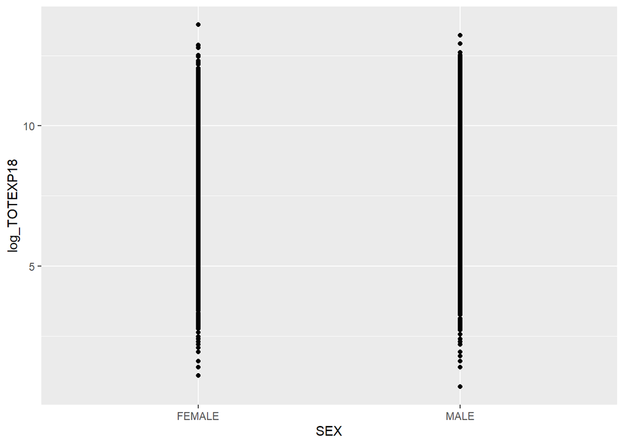

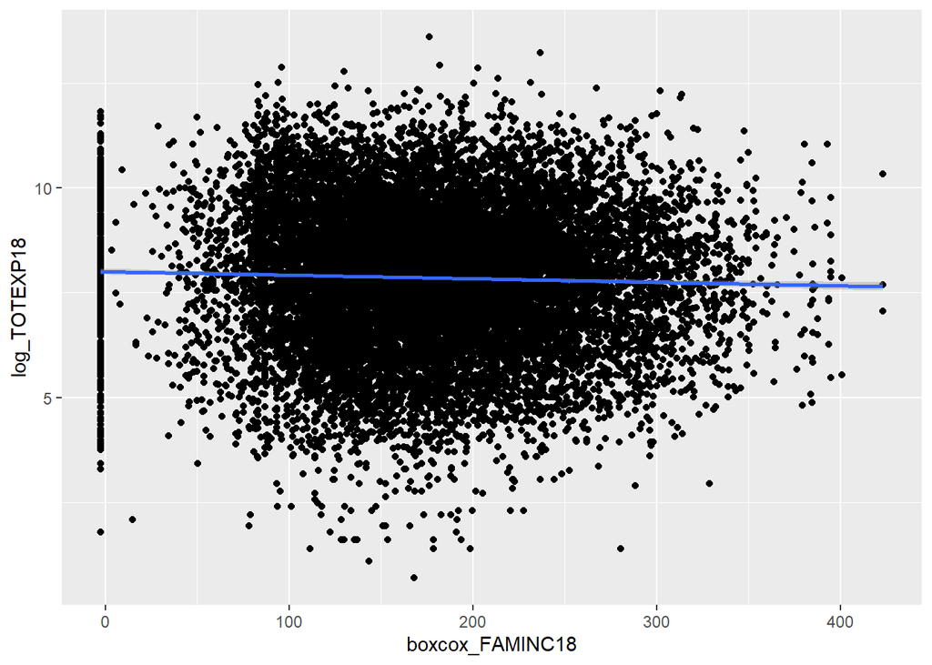

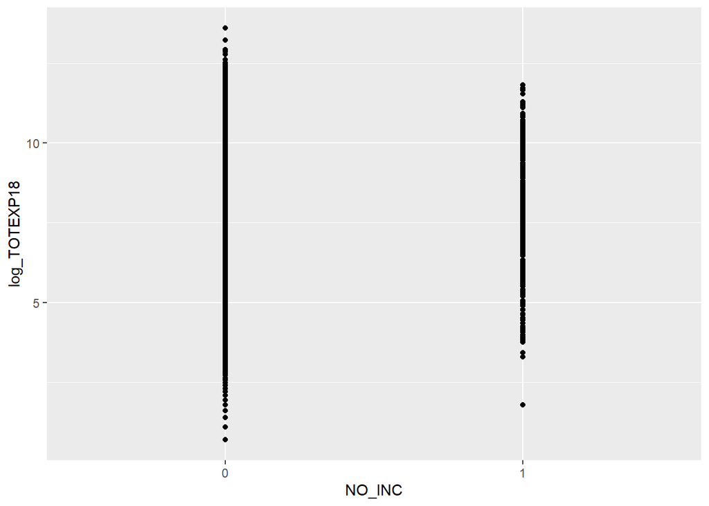

```r
for (col in colnames(data)[!colnames(data) %in% c('log_TOTEXP18','boxcox_TOTEXP18','TOTEXP18','FAMINC18')]) {
  plot = ggplot(data, aes(x = !!sym(col), y = log_TOTEXP18)) + geom_point() + geom_smooth(method = "lm")
  print(plot)
}
```

```r
cat('\nObservations in orignal data = ', nrow(data_raw))
```

```
##
## Observations in orignal data =  18252
```

```r
cat('\nObservations in cleaned data = ', nrow(data))
```

```
##
## Observations in cleaned data =  15724
```

```r
cat('\nObservations in removed = ', nrow(data_raw)-nrow(data))
```

```
##
## Observations in removed =  2528
```

```r
# I will use log transformed total expenditure
```

### Time for model building and variable selection. I will create all first order terms, interaction terms, and b-spline transformed BMI to choose from.

```r
response = "log_TOTEXP18"
first_order_terms = setdiff(colnames(data), c("log_TOTEXP18", "boxcox_TOTEXP18","TOTEXP18", "ADBMI42", "AGE42X", "FAMINC18", "boxcox_FAMINC18"))
interaction_terms = combn(first_order_terms, 2, FUN = function(x) paste(x[1], x[2], sep = ":"))
b_spline_terms = "bs(ADBMI42, degree = 4) + bs(AGE42X, degree = 4) + bs(boxcox_FAMINC18, degree = 3)"
quadratic_terms = "I(ADBMI42^2)"

# combine
all_terms = c(first_order_terms, interaction_terms, b_spline_terms)

# formula string
# formula_string = paste(all_terms, collapse = " + ")
formula_string <- paste(response," ~", paste(all_terms, collapse = " + "))
model_formula <- as.formula(formula_string)
print(model_formula)
```

```
## log_TOTEXP18 ~ MNHLTH42 + RACETHX + SEX + NO_INC + MNHLTH42:RACETHX +
##     MNHLTH42:SEX + MNHLTH42:NO_INC + RACETHX:SEX + RACETHX:NO_INC +
##     SEX:NO_INC + bs(ADBMI42, degree = 4) + bs(AGE42X, degree = 4) +
##     bs(boxcox_FAMINC18, degree = 3)
```

### Full model

```r
full_model = lm(model_formula, data = data)
summary(full_model)
```

```
##
## Call:
## lm(formula = model_formula, data = data)
##
## Residuals:
##     Min      1Q  Median      3Q     Max
## -6.6441 -0.9752  0.0374  1.0128  6.2243
##
## Coefficients:
##                                             Estimate Std. Error t value
## (Intercept)                                 7.424503   0.449424  16.520
## MNHLTH42FAIR                                1.106175   0.270893   4.083
## MNHLTH42GOOD                                0.106991   0.149790   0.714
## MNHLTH42POOR                                1.448945   0.506252   2.862
## MNHLTH42VERY GOOD                           0.083000   0.136102   0.610
## RACETHXBLACK ONLY                           0.194320   0.126138   1.541
## RACETHXHISPANIC                             0.151690   0.123454   1.229
## RACETHXOTHER OR MULTIPLE                    0.749220   0.181473   4.129
## RACETHXWHITE ONLY                           0.590796   0.112044   5.273
## SEXMALE                                    -0.108379   0.117448  -0.923
## NO_INC1                                    -1.528080   0.502635  -3.040
## bs(ADBMI42, degree = 4)1                   -1.385167   0.920936  -1.504
## bs(ADBMI42, degree = 4)2                   -0.096251   0.465587  -0.207
## bs(ADBMI42, degree = 4)3                    0.547807   0.921680   0.594
## bs(ADBMI42, degree = 4)4                    0.158928   0.513603   0.309
## bs(AGE42X, degree = 4)1                     0.531884   0.203791   2.610
## bs(AGE42X, degree = 4)2                    -0.001142   0.184626  -0.006
## bs(AGE42X, degree = 4)3                     2.173903   0.178098  12.206
## bs(AGE42X, degree = 4)4                     1.769197   0.079462  22.265
## bs(boxcox_FAMINC18, degree = 3)1           -1.556297   0.409934  -3.796
## bs(boxcox_FAMINC18, degree = 3)2            0.258861   0.182317   1.420
## bs(boxcox_FAMINC18, degree = 3)3           -0.476589   0.371924  -1.281
## MNHLTH42FAIR:RACETHXBLACK ONLY             -0.212087   0.292241  -0.726
## MNHLTH42GOOD:RACETHXBLACK ONLY              0.326341   0.168951   1.932
## MNHLTH42POOR:RACETHXBLACK ONLY             -0.096960   0.561638  -0.173
## MNHLTH42VERY GOOD:RACETHXBLACK ONLY         0.145177   0.158738   0.915
## MNHLTH42FAIR:RACETHXHISPANIC               -0.234372   0.288709  -0.812
## MNHLTH42GOOD:RACETHXHISPANIC                0.133100   0.165514   0.804
## MNHLTH42POOR:RACETHXHISPANIC                0.234972   0.539383   0.436
## MNHLTH42VERY GOOD:RACETHXHISPANIC          -0.020070   0.155023  -0.129
```

[output cut: 72 more lines]

```
## RACETHXBLACK ONLY:SEXMALE                  0.171043
## RACETHXHISPANIC:SEXMALE                    0.008496 **
## RACETHXOTHER OR MULTIPLE:SEXMALE           0.002193 **
## RACETHXWHITE ONLY:SEXMALE                  0.053740 .
## RACETHXBLACK ONLY:NO_INC1                  0.087063 .
## RACETHXHISPANIC:NO_INC1                    0.336722
## RACETHXOTHER OR MULTIPLE:NO_INC1           0.795697
## RACETHXWHITE ONLY:NO_INC1                  0.025798 *
## SEXMALE:NO_INC1                            0.499852
## ---
## Signif. codes:  0 '***' 0.001 '**' 0.01 '*' 0.05 '.' 0.1 ' ' 1
##
## Residual standard error: 1.515 on 15669 degrees of freedom
## Multiple R-squared:  0.196,  Adjusted R-squared:  0.1933
## F-statistic: 70.75 on 54 and 15669 DF,  p-value: < 2.2e-16
```

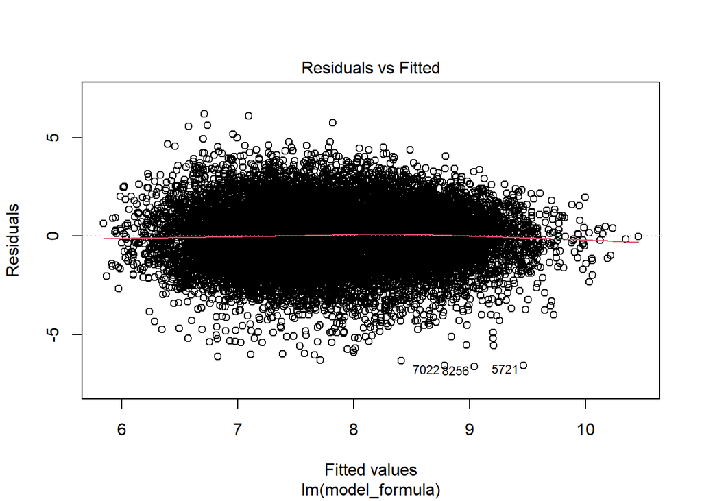

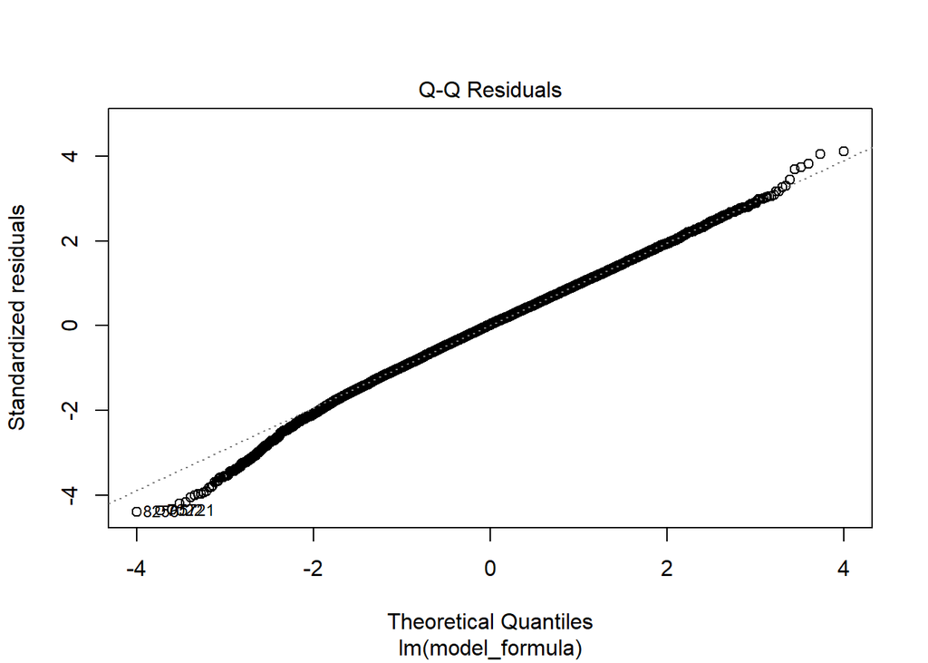

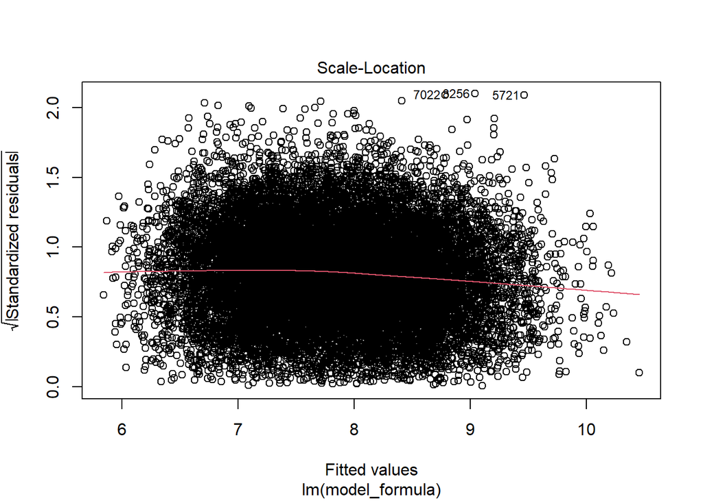

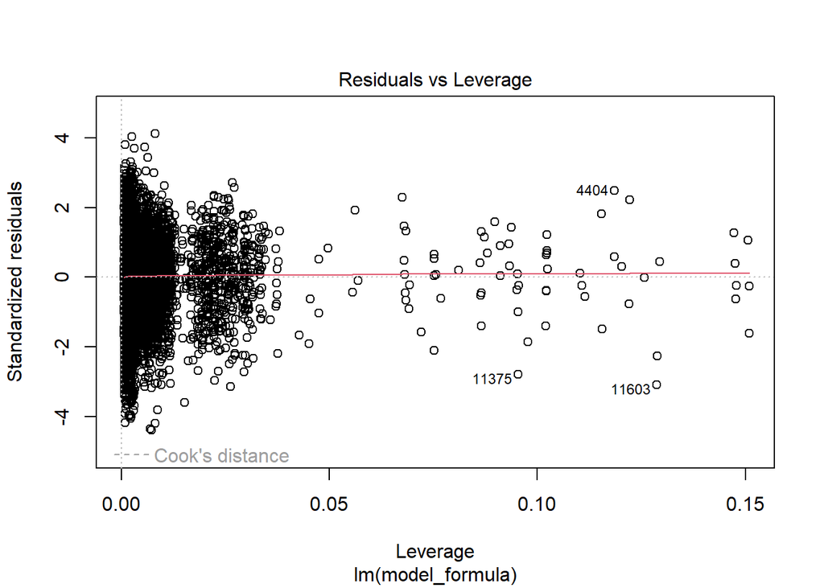

```r
plot(full_model)
```

### Stepwise variable selection (AIC)

```r
null_model = lm(log_TOTEXP18~1, data=data)
stepwise = step(null_model, scope = list(lower = null_model, upper = full_model), direction = "both", k = 2, trace = FALSE, test = "F", steps = 1000, add = 0.05 , drop = 0.05)
summary(stepwise)
```

```
##
## Call:
## lm(formula = log_TOTEXP18 ~ bs(AGE42X, degree = 4) + MNHLTH42 +
##     RACETHX + SEX + bs(ADBMI42, degree = 4) + bs(boxcox_FAMINC18,
##     degree = 3) + NO_INC + RACETHX:SEX + RACETHX:NO_INC, data = data)
##
## Residuals:
##     Min      1Q  Median      3Q     Max
## -6.6353 -0.9784  0.0346  1.0071  6.1133
##
## Coefficients:
##                                  Estimate Std. Error t value Pr(>|t|)
## (Intercept)                       7.36057    0.44328  16.605  < 2e-16 ***
## bs(AGE42X, degree = 4)1           0.54598    0.20372   2.680 0.007368 **
## bs(AGE42X, degree = 4)2          -0.01287    0.18451  -0.070 0.944405
## bs(AGE42X, degree = 4)3           2.18346    0.17788  12.275  < 2e-16 ***
## bs(AGE42X, degree = 4)4           1.77610    0.07939  22.373  < 2e-16 ***
## MNHLTH42FAIR                      0.90514    0.04875  18.567  < 2e-16 ***
## MNHLTH42GOOD                      0.37487    0.03267  11.476  < 2e-16 ***
## MNHLTH42POOR                      1.32665    0.09390  14.129  < 2e-16 ***
## MNHLTH42VERY GOOD                 0.12009    0.03062   3.922 8.83e-05 ***
## RACETHXBLACK ONLY                 0.31155    0.08731   3.568 0.000361 ***
## RACETHXHISPANIC                   0.16812    0.08491   1.980 0.047738 *
## RACETHXOTHER OR MULTIPLE          0.73528    0.11749   6.258 4.00e-10 ***
## RACETHXWHITE ONLY                 0.65255    0.07784   8.384  < 2e-16 ***
## SEXMALE                          -0.07344    0.11198  -0.656 0.511972
## bs(ADBMI42, degree = 4)1         -1.41210    0.92067  -1.534 0.125103
## bs(ADBMI42, degree = 4)2         -0.09423    0.46521  -0.203 0.839489
## bs(ADBMI42, degree = 4)3          0.50761    0.92138   0.551 0.581692
## bs(ADBMI42, degree = 4)4          0.16976    0.51330   0.331 0.740863
## bs(boxcox_FAMINC18, degree = 3)1 -1.55115    0.40921  -3.791 0.000151 ***
## bs(boxcox_FAMINC18, degree = 3)2  0.26138    0.18219   1.435 0.151409
## bs(boxcox_FAMINC18, degree = 3)3 -0.47465    0.37160  -1.277 0.201509
## NO_INC1                          -1.36304    0.45830  -2.974 0.002943 **
## RACETHXBLACK ONLY:SEXMALE        -0.18516    0.13078  -1.416 0.156832
## RACETHXHISPANIC:SEXMALE          -0.34240    0.12747  -2.686 0.007238 **
## RACETHXOTHER OR MULTIPLE:SEXMALE -0.55270    0.17861  -3.095 0.001975 **
## RACETHXWHITE ONLY:SEXMALE        -0.23362    0.11609  -2.012 0.044186 *
## RACETHXBLACK ONLY:NO_INC1         0.75310    0.45230   1.665 0.095927 .
## RACETHXHISPANIC:NO_INC1           0.41835    0.45409   0.921 0.356916
## RACETHXOTHER OR MULTIPLE:NO_INC1  0.15877    0.64410   0.247 0.805296
## RACETHXWHITE ONLY:NO_INC1         0.99382    0.44541   2.231 0.025678 *
## ---
## Signif. codes:  0 '***' 0.001 '**' 0.01 '*' 0.05 '.' 0.1 ' ' 1
##
## Residual standard error: 1.515 on 15694 degrees of freedom
## Multiple R-squared:  0.1946, Adjusted R-squared:  0.1931
## F-statistic: 130.7 on 29 and 15694 DF,  p-value: < 2.2e-16
```

```r
cat('\nNumber of terms = ',length(coef(stepwise))-1)
```

```
##
## Number of terms =  29
```

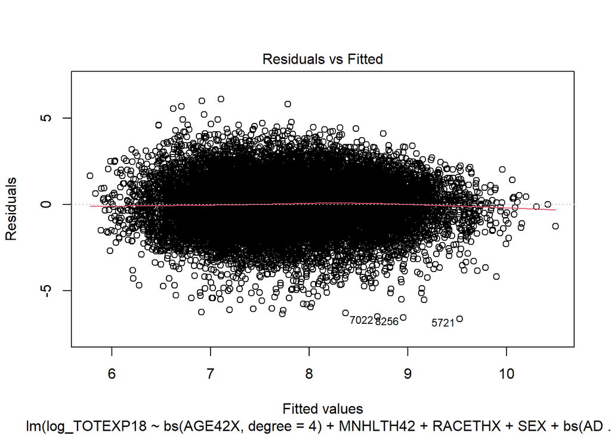

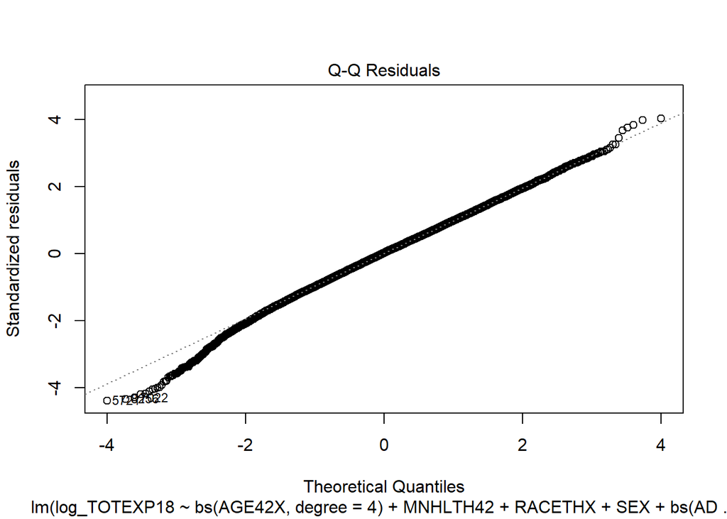

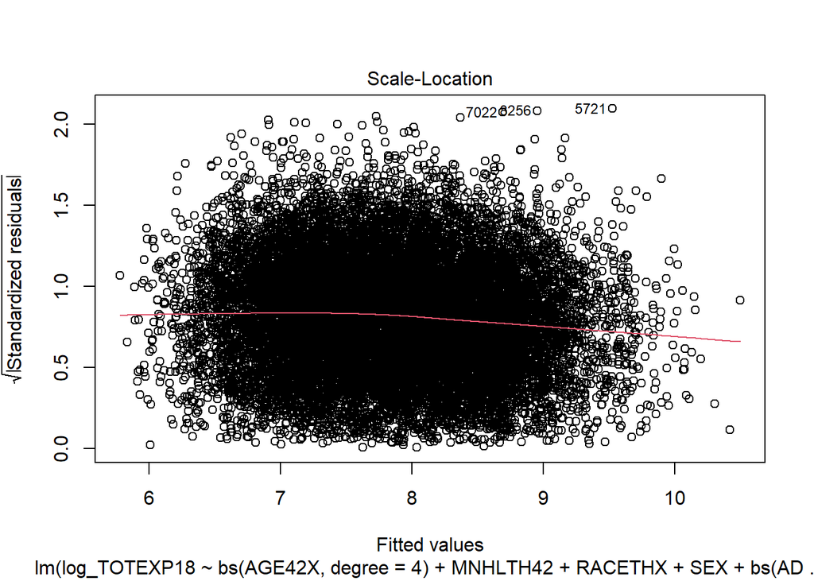

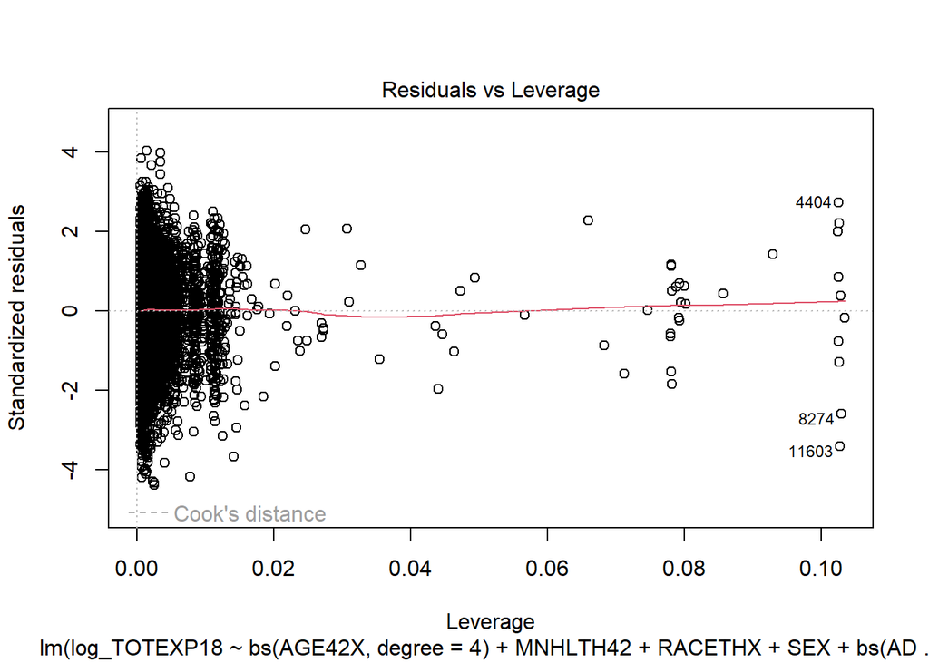

```r
plot(stepwise)
```

### Lasso variable selection

```r
library(glmnet)
```

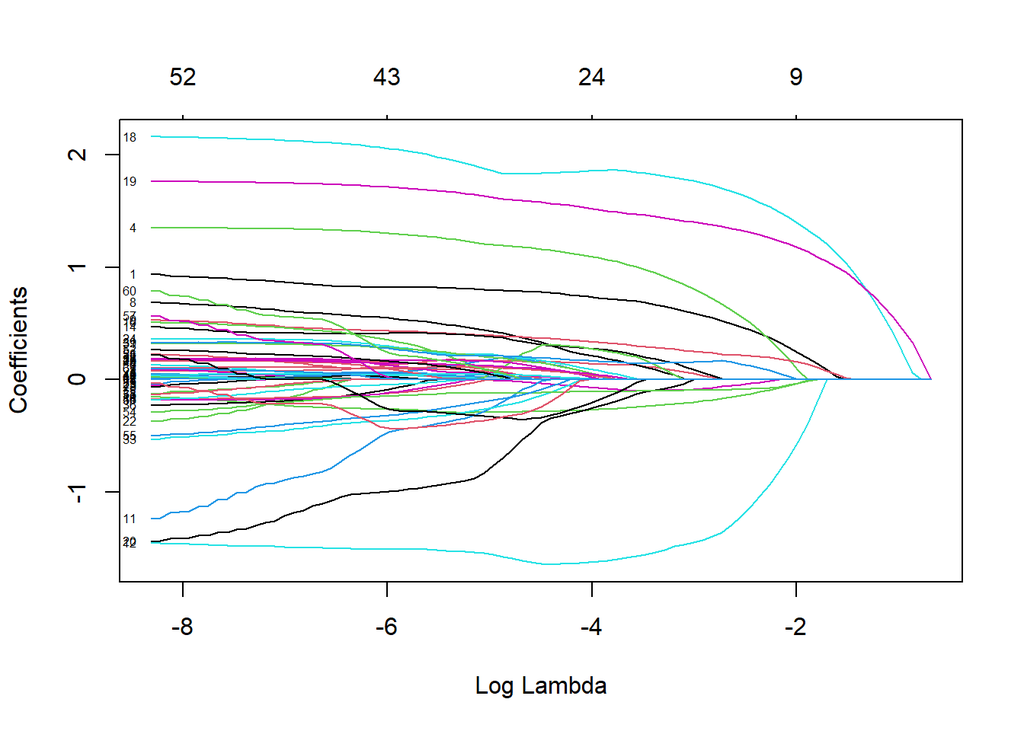

```r
X = model.matrix(model_formula, data = data)[, -1]

# lasso model
lasso = glmnet(x = X, y = data$log_TOTEXP18, alpha = 1)
plot(lasso, xvar = "lambda", label = TRUE)
```

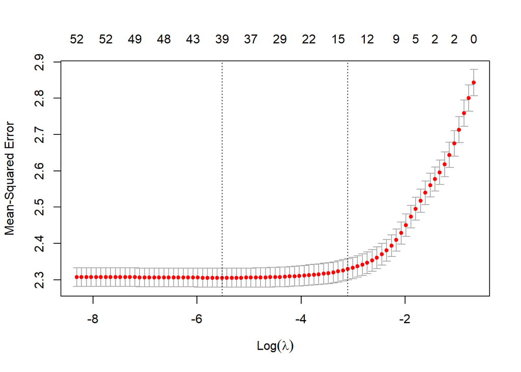

```r
# cv to find optimal lambda
cv_lasso = cv.glmnet(x = X, y = data$log_TOTEXP18, alpha = 1, nfolds = 10)
plot(cv_lasso)
```

```r
best_lambda = cv_lasso$lambda.min
cat("Best lambda from cross-validation:", best_lambda, "\n")
```

```
## Best lambda from cross-validation: 0.00400272
```

```r
# use optimal lambda to fit best model
best_lasso = glmnet(x = X, y = data$log_TOTEXP18, alpha = 1, lambda = best_lambda)
coefficients_best_lasso = coef(best_lasso)
print(coefficients_best_lasso)
```

```
## 62 x 1 sparse Matrix of class "dgCMatrix"
##                                                       s0
## (Intercept)                                 7.5194231528
## MNHLTH42FAIR                                0.8197911964
## MNHLTH42GOOD                                0.1725829549
## MNHLTH42INVALID                             .
## MNHLTH42POOR                                1.2667233038
## MNHLTH42VERY GOOD                           0.0403719872
## RACETHXBLACK ONLY                           0.0307027836
## RACETHXHISPANIC                             .
## RACETHXOTHER OR MULTIPLE                    0.5068335078
## RACETHXWHITE ONLY                           0.4199159745
## SEXMALE                                    -0.2765963034
## NO_INC1                                    -0.3921935415
## bs(ADBMI42, degree = 4)1                   -1.6029960736
## bs(ADBMI42, degree = 4)2                    .
## bs(ADBMI42, degree = 4)3                    0.3460983496
## bs(ADBMI42, degree = 4)4                    0.0993183580
## bs(AGE42X, degree = 4)1                     0.2552658983
## bs(AGE42X, degree = 4)2                     0.1014457386
## bs(AGE42X, degree = 4)3                     1.9942629548
## bs(AGE42X, degree = 4)4                     1.6837310491
## bs(boxcox_FAMINC18, degree = 3)1           -0.9418546330
## bs(boxcox_FAMINC18, degree = 3)2            0.0912136047
## bs(boxcox_FAMINC18, degree = 3)3            .
## MNHLTH42FAIR:RACETHXBLACK ONLY              0.0507873675
## MNHLTH42GOOD:RACETHXBLACK ONLY              0.2409113824
## MNHLTH42INVALID:RACETHXBLACK ONLY           .
## MNHLTH42POOR:RACETHXBLACK ONLY              .
## MNHLTH42VERY GOOD:RACETHXBLACK ONLY         0.1684019325
## MNHLTH42FAIR:RACETHXHISPANIC                0.0005834217
## MNHLTH42GOOD:RACETHXHISPANIC                0.0239758147
## MNHLTH42INVALID:RACETHXHISPANIC             .
## MNHLTH42POOR:RACETHXHISPANIC                0.2544373459
## MNHLTH42VERY GOOD:RACETHXHISPANIC           .
## MNHLTH42FAIR:RACETHXOTHER OR MULTIPLE      -0.3250564148
## MNHLTH42GOOD:RACETHXOTHER OR MULTIPLE       0.0752525446
## MNHLTH42INVALID:RACETHXOTHER OR MULTIPLE    .
## MNHLTH42POOR:RACETHXOTHER OR MULTIPLE       .
## MNHLTH42VERY GOOD:RACETHXOTHER OR MULTIPLE  0.1072200695
```

[output cut: 9 more lines]

```
## MNHLTH42VERY GOOD:SEXMALE                   .
## MNHLTH42FAIR:NO_INC1                        .
## MNHLTH42GOOD:NO_INC1                        .
## MNHLTH42INVALID:NO_INC1                     .
## MNHLTH42POOR:NO_INC1                       -0.0543075334
## MNHLTH42VERY GOOD:NO_INC1                   0.1269345588
## RACETHXBLACK ONLY:SEXMALE                   .
## RACETHXHISPANIC:SEXMALE                    -0.1282326266
## RACETHXOTHER OR MULTIPLE:SEXMALE           -0.2657238557
## RACETHXWHITE ONLY:SEXMALE                  -0.0220612748
## RACETHXBLACK ONLY:NO_INC1                   .
## RACETHXHISPANIC:NO_INC1                    -0.2906400232
## RACETHXOTHER OR MULTIPLE:NO_INC1           -0.4104835460
## RACETHXWHITE ONLY:NO_INC1                   0.1777055987
## SEXMALE:NO_INC1                             .
```

```r
summary(best_lasso)
```

```
##           Length Class     Mode
## a0         1     -none-    numeric
## beta      61     dgCMatrix S4
## df         1     -none-    numeric
## dim        2     -none-    numeric
## lambda     1     -none-    numeric
## dev.ratio  1     -none-    numeric
## nulldev    1     -none-    numeric
## npasses    1     -none-    numeric
## jerr       1     -none-    numeric
## offset     1     -none-    logical
## call       5     -none-    call
## nobs       1     -none-    numeric
```

```r
# num non zero coeff
non_zero_coeffs = sum(coefficients_best_lasso != 0)
cat("\nNumber of non-zero coefficients:", non_zero_coeffs, "\n")
```

```
##
## Number of non-zero coefficients: 40
```

```r
# DIAGNOSTICS:
# Predict using the best Lasso model
y_pred = predict(best_lasso, X)

# Compute residuals
residuals = data$log_TOTEXP18 - y_pred

# Compute R-squared (1 - RSS/TSS)
rss = sum(residuals^2)
tss = sum((data$log_TOTEXP18 - mean(data$log_TOTEXP18))^2)
r_squared = 1 - rss / tss
cat("\nR-squared:", r_squared, "\n")
```

```
##
## R-squared: 0.1950217
```

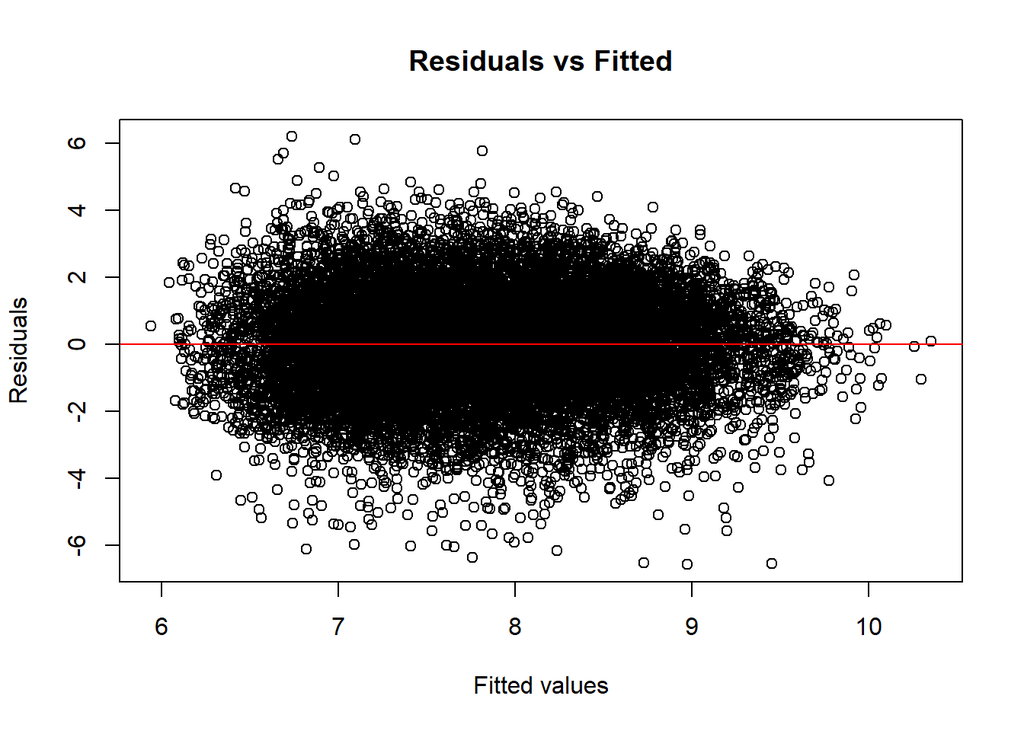

```r
# Plot 1: Residuals vs Fitted Values
plot(y_pred, residuals, xlab = "Fitted values", ylab = "Residuals", main = "Residuals vs Fitted")
abline(h = 0, col = "red")
```

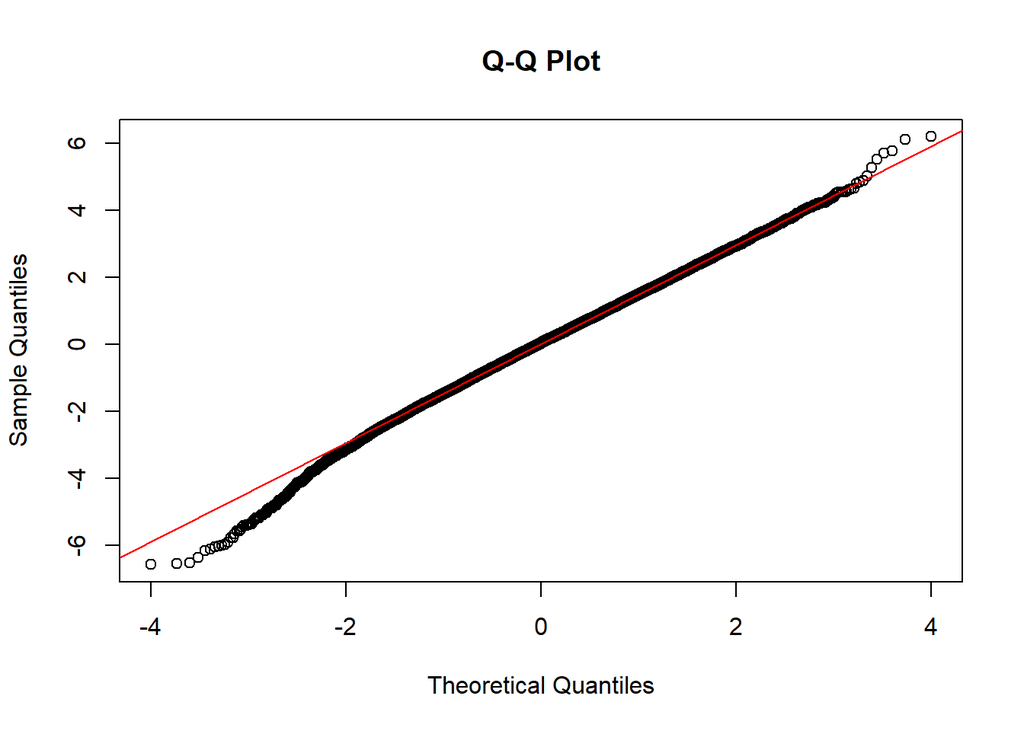

```r
# Plot 2: Q-Q plot of residuals
qqnorm(residuals, main = "Q-Q Plot")
qqline(residuals, col = "red")
```

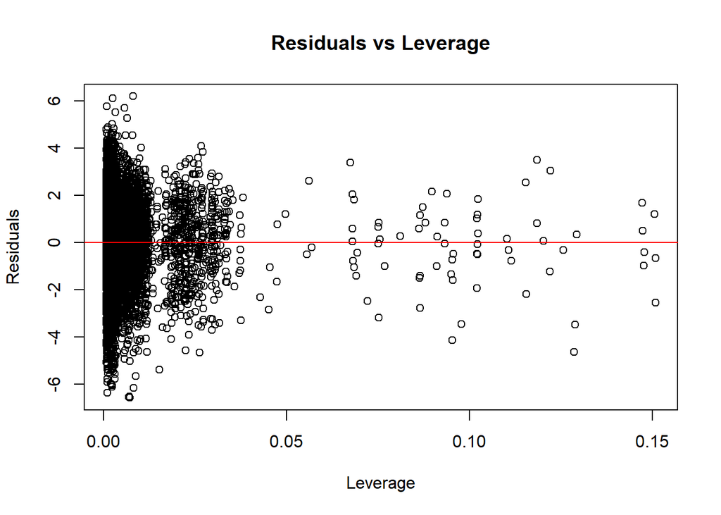

```r
# Plot 3: Residuals vs Leverage plot
leverage = hatvalues(lm(data$log_TOTEXP18 ~ X))

plot(leverage, residuals, xlab = "Leverage", ylab = "Residuals", main = "Residuals vs Leverage")
abline(h = 0, col = "red")
```

## Problem 3:

### Independence assumption:

### Satisfied. The 3 continuous variables are not correlated.

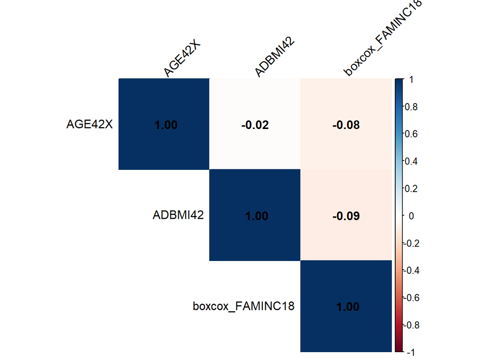

```r
# correlation matrix
cor_matrix = cor(data[, c("AGE42X", "ADBMI42", "boxcox_FAMINC18")], use = "complete.obs")
corrplot(cor_matrix, method = "color", type = "upper", tl.col = "black", tl.srt = 45, addCoef.col = "black")
```

### Linearity and constant variance of residuals assumptions:

### Linearity is satisfied. The resdiuals vs fitted plot does not show any non-linear pattern.

### The residuals also have mostly constant variance but there is a slight football shape. Also a trend of decreasing variance as fitted value increases.

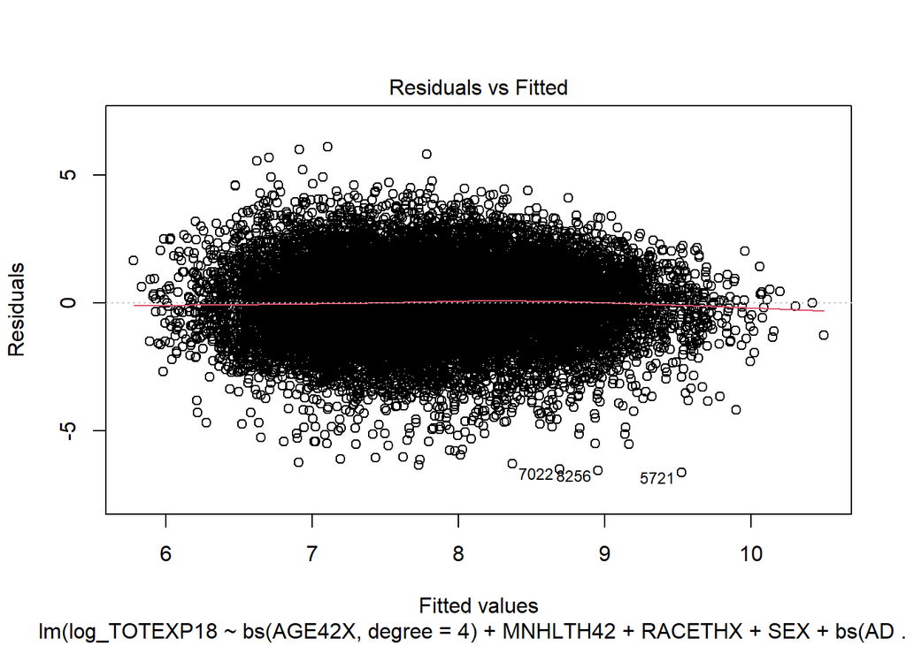

```r
plot(stepwise, which=1)
```

### I will try a weighted least squares model to resolve the slight heteroscedasticity.

### I tried several methods and neither improved the heteroscedasticity. They seemed to make everything else worse though.

```r
residuals = resid(stepwise)
variance_model = lm(I(residuals^2) ~ data$log_TOTEXP18)
fitted_variance = predict(variance_model)
weights = 1 / fitted_variance

# weights = 1 / fitted(stepwise)^2

wls_model = lm(formula(stepwise), data = data, weights = weights)
summary(wls_model)
```

```
##
## Call:
## lm(formula = formula(stepwise), data = data, weights = weights)
##
## Weighted Residuals:
##     Min      1Q  Median      3Q     Max
## -3.6068 -0.7845 -0.1526  0.5189  6.2711
##
## Coefficients:
##                                  Estimate Std. Error t value Pr(>|t|)
## (Intercept)                       7.69940    0.45233  17.022  < 2e-16 ***
## bs(AGE42X, degree = 4)1           0.47624    0.20990   2.269 0.023285 *
## bs(AGE42X, degree = 4)2           0.28899    0.18340   1.576 0.115103
## bs(AGE42X, degree = 4)3           2.01852    0.17622  11.455  < 2e-16 ***
## bs(AGE42X, degree = 4)4           1.74308    0.07976  21.853  < 2e-16 ***
## MNHLTH42FAIR                      0.90703    0.04722  19.207  < 2e-16 ***
## MNHLTH42GOOD                      0.39262    0.03271  12.003  < 2e-16 ***
## MNHLTH42POOR                      1.29946    0.08818  14.736  < 2e-16 ***
## MNHLTH42VERY GOOD                 0.11402    0.03097   3.681 0.000233 ***
## RACETHXBLACK ONLY                 0.36759    0.08967   4.099 4.16e-05 ***
## RACETHXHISPANIC                   0.23649    0.08763   2.699 0.006967 **
## RACETHXOTHER OR MULTIPLE          0.78202    0.11792   6.632 3.42e-11 ***
## RACETHXWHITE ONLY                 0.67418    0.08034   8.392  < 2e-16 ***
## SEXMALE                          -0.02627    0.11599  -0.227 0.820803
## bs(ADBMI42, degree = 4)1         -1.42523    0.93734  -1.521 0.128403
## bs(ADBMI42, degree = 4)2         -0.18771    0.45368  -0.414 0.679070
## bs(ADBMI42, degree = 4)3          0.50017    0.91665   0.546 0.585313
## bs(ADBMI42, degree = 4)4          0.19636    0.50423   0.389 0.696973
## bs(boxcox_FAMINC18, degree = 3)1 -1.66603    0.40825  -4.081 4.51e-05 ***
## bs(boxcox_FAMINC18, degree = 3)2  0.10235    0.18214   0.562 0.574190
## bs(boxcox_FAMINC18, degree = 3)3 -0.57693    0.37173  -1.552 0.120679
## NO_INC1                          -1.50957    0.48564  -3.108 0.001884 **
## RACETHXBLACK ONLY:SEXMALE        -0.16338    0.13450  -1.215 0.224495
## RACETHXHISPANIC:SEXMALE          -0.37048    0.13193  -2.808 0.004989 **
## RACETHXOTHER OR MULTIPLE:SEXMALE -0.61475    0.18169  -3.384 0.000717 ***
## RACETHXWHITE ONLY:SEXMALE        -0.23112    0.11987  -1.928 0.053871 .
## RACETHXBLACK ONLY:NO_INC1         0.88810    0.47956   1.852 0.064061 .
## RACETHXHISPANIC:NO_INC1           0.55156    0.48279   1.142 0.253281
## RACETHXOTHER OR MULTIPLE:NO_INC1  0.62457    0.67018   0.932 0.351376
## RACETHXWHITE ONLY:NO_INC1         1.08176    0.47244   2.290 0.022051 *
## ---
## Signif. codes:  0 '***' 0.001 '**' 0.01 '*' 0.05 '.' 0.1 ' ' 1
##
## Residual standard error: 1.019 on 15694 degrees of freedom
## Multiple R-squared:  0.1868, Adjusted R-squared:  0.1853
## F-statistic: 124.3 on 29 and 15694 DF,  p-value: < 2.2e-16
```

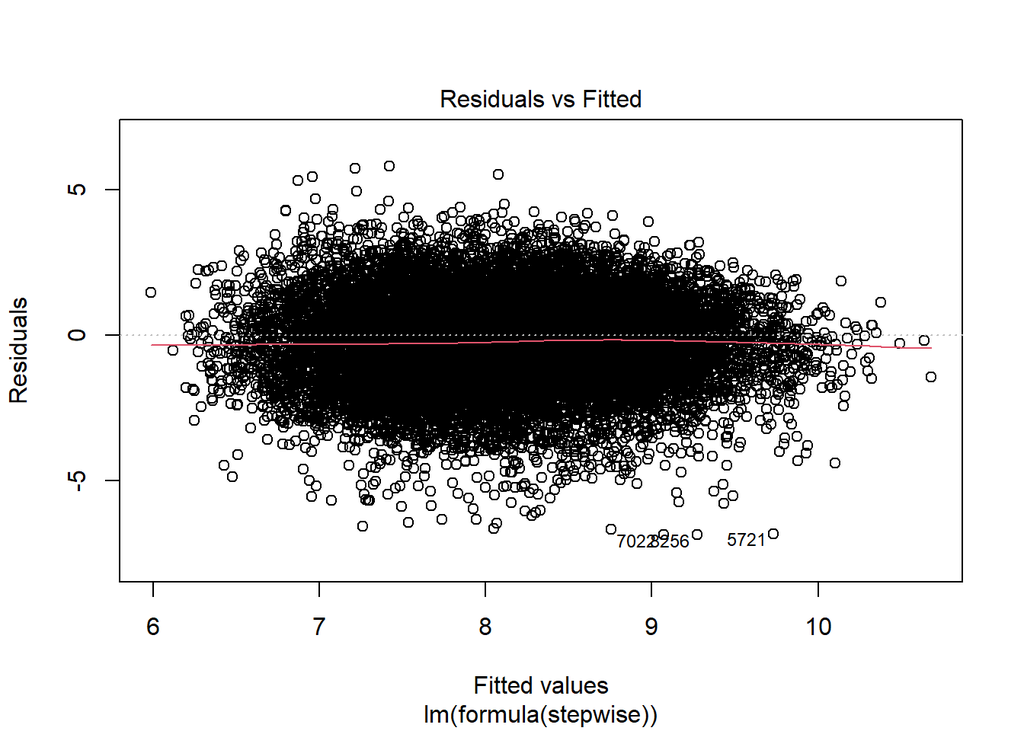

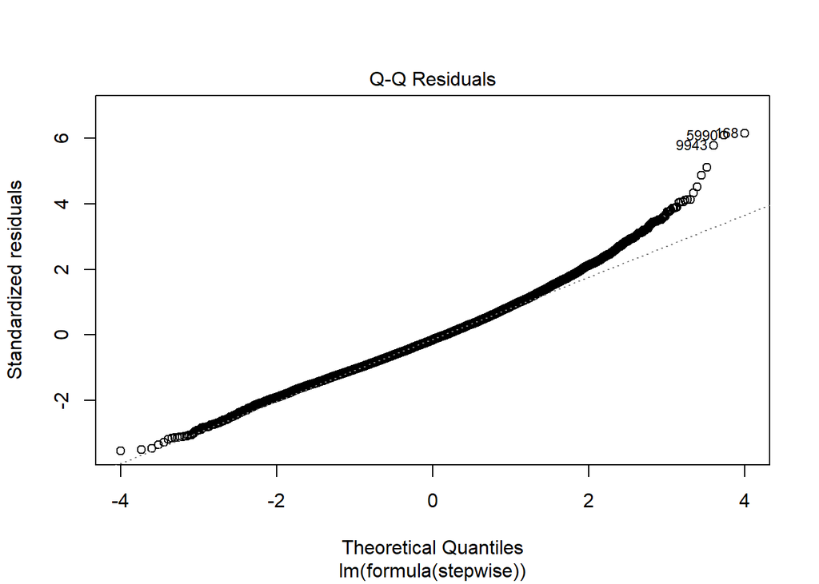

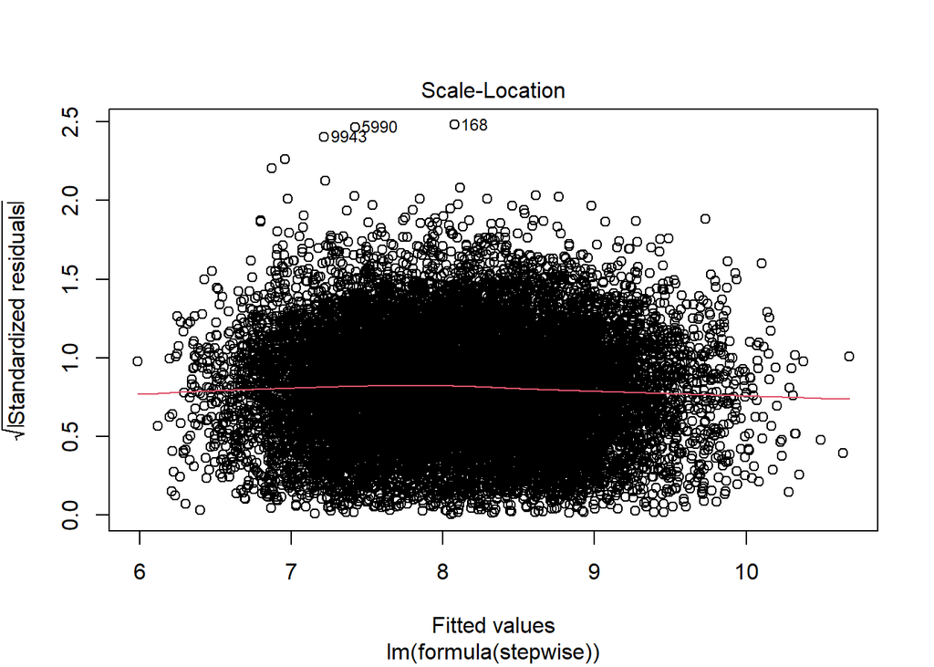

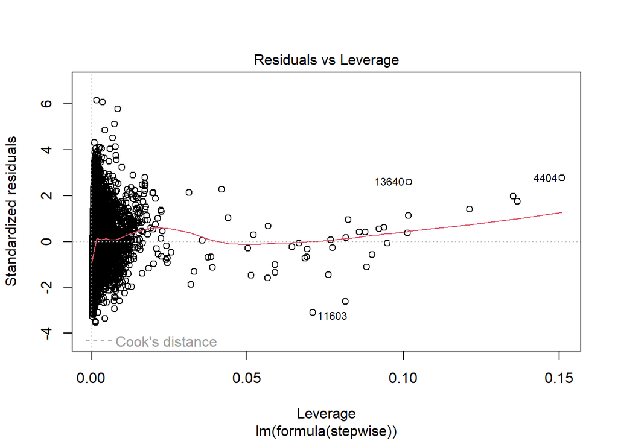

```r
plot(wls_model)
```

### I am willing to accept the level of heteroscedasticity in the stepwise model. It does not seem extreme enough to me to be a problem.

### Normality of residuals assumption:

### Satisfied.

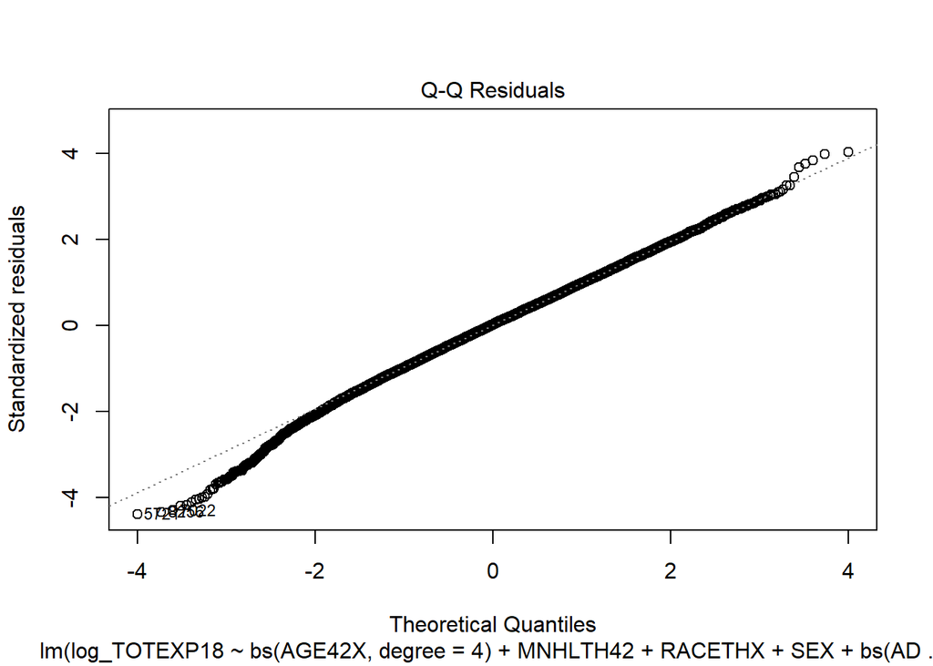

```r
plot(stepwise, which=2)
```

### Multicollinearity:

### I got rid of the b-spline transformations and interaction terms. The variance inflation factors (VIFs) are all close to 1 which means no collinearity.

```r
library(car)
# stepwise formula: log_TOTEXP18 ~ bs(AGE42X, degree = 4) + MNHLTH42 + RACETHX + SEX + bs(ADBMI42, degree = 4) + bs(boxcox_FAMINC18, degree = 3) + NO_INC + RACETHX:SEX + RACETHX:NO_INC

linear_model = lm(log_TOTEXP18 ~ AGE42X + MNHLTH42 + RACETHX + SEX + ADBMI42 + boxcox_FAMINC18 + NO_INC, data=data)
vif(linear_model)
```

```
##                     GVIF Df GVIF^(1/(2*Df))
## AGE42X          1.042501  1        1.021030
## MNHLTH42        1.105761  4        1.012646
## RACETHX         1.131593  4        1.015573
## SEX             1.012918  1        1.006438
## ADBMI42         1.046438  1        1.022955
## boxcox_FAMINC18 1.362076  1        1.167080
## NO_INC          1.192080  1        1.091824
```

## Problem 4:

### 95% confidence intervals for coefficients.

### Looks like a good chuck of the confidence intervals include 0.

```r
conf_intervals = confint(stepwise, level = 0.95)
print(conf_intervals)
```

```
##                                         2.5 %       97.5 %
## (Intercept)                       6.491689857  8.229443464
## bs(AGE42X, degree = 4)1           0.146668481  0.945296092
## bs(AGE42X, degree = 4)2          -0.374536073  0.348801792
## bs(AGE42X, degree = 4)3           1.834782365  2.532129379
## bs(AGE42X, degree = 4)4           1.620493765  1.931710871
## MNHLTH42FAIR                      0.809582836  1.000698195
## MNHLTH42GOOD                      0.310838975  0.438894666
## MNHLTH42POOR                      1.142607206  1.510701410
## MNHLTH42VERY GOOD                 0.060064235  0.180107234
## RACETHXBLACK ONLY                 0.140405538  0.482696662
## RACETHXHISPANIC                   0.001675799  0.334561157
## RACETHXOTHER OR MULTIPLE          0.504978921  0.965580226
## RACETHXWHITE ONLY                 0.499979154  0.805117477
## SEXMALE                          -0.292938649  0.146063810
## bs(ADBMI42, degree = 4)1         -3.216720595  0.392511205
## bs(ADBMI42, degree = 4)2         -1.006092692  0.817635734
## bs(ADBMI42, degree = 4)3         -1.298404263  2.313632098
## bs(ADBMI42, degree = 4)4         -0.836368260  1.175881409
## bs(boxcox_FAMINC18, degree = 3)1 -2.353244129 -0.749061011
## bs(boxcox_FAMINC18, degree = 3)2 -0.095735491  0.618488232
## bs(boxcox_FAMINC18, degree = 3)3 -1.203024455  0.253726553
## NO_INC1                          -2.261346928 -0.464723373
## RACETHXBLACK ONLY:SEXMALE        -0.441495518  0.071172956
## RACETHXHISPANIC:SEXMALE          -0.592269009 -0.092538335
## RACETHXOTHER OR MULTIPLE:SEXMALE -0.902787329 -0.202612313
## RACETHXWHITE ONLY:SEXMALE        -0.461162421 -0.006079689
## RACETHXBLACK ONLY:NO_INC1        -0.133468569  1.639667986
## RACETHXHISPANIC:NO_INC1          -0.471723640  1.308416768
## RACETHXOTHER OR MULTIPLE:NO_INC1 -1.103731506  1.421276062
## RACETHXWHITE ONLY:NO_INC1         0.120770538  1.866869191
```

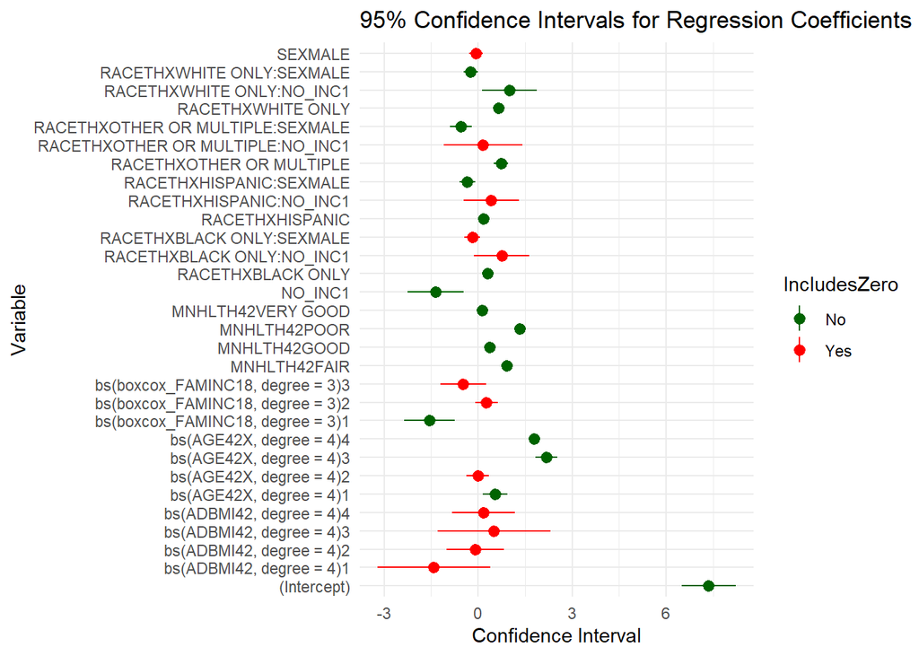

```r
# Convert to data frame for plotting
conf_intervals_df <- as.data.frame(conf_intervals)
conf_intervals_df$Variable <- rownames(conf_intervals_df)  # Add variable names as a column

# Create a new column to indicate if the confidence interval includes 0
conf_intervals_df$IncludesZero <- ifelse(conf_intervals_df$`2.5 %` > 0 | conf_intervals_df$`97.5 %` < 0, "No", "Yes")

# Plot the confidence intervals
ggplot(conf_intervals_df, aes(x = Variable, ymin = `2.5 %`, ymax = `97.5 %`, color = IncludesZero)) +
  geom_pointrange(aes(y = ( `2.5 %` + `97.5 %` ) / 2)) +  # Use midpoint for 'y'
  coord_flip() +  # Flip coordinates to make the plot horizontal
  theme_minimal() +
  labs(
    title = "95% Confidence Intervals for Regression Coefficients",
    x = "Variable",
    y = "Confidence Interval"
  ) +
  scale_color_manual(values = c("Yes" = "red", "No" = "darkgreen"))
```

# I will also fit a simple model just to see how it performs.

```r
simple_model = lm(log_TOTEXP18 ~ AGE42X + ADBMI42 + MNHLTH42 + RACETHX + SEX + boxcox_FAMINC18 + NO_INC, data=data)
summary(simple_model)
```

```
##
## Call:
## lm(formula = log_TOTEXP18 ~ AGE42X + ADBMI42 + MNHLTH42 + RACETHX +
##     SEX + boxcox_FAMINC18 + NO_INC, data = data)
##
## Residuals:
##     Min      1Q  Median      3Q     Max
## -6.7450 -0.9841  0.0423  1.0168  6.0460
##
## Coefficients:
##                            Estimate Std. Error t value Pr(>|t|)
## (Intercept)               5.0269769  0.0934662  53.784  < 2e-16 ***
## AGE42X                    0.0305724  0.0006848  44.647  < 2e-16 ***
## ADBMI42                   0.0206268  0.0017402  11.853  < 2e-16 ***
## MNHLTH42FAIR              0.9107021  0.0487434  18.684  < 2e-16 ***
## MNHLTH42GOOD              0.3582367  0.0327063  10.953  < 2e-16 ***
## MNHLTH42POOR              1.3140116  0.0939775  13.982  < 2e-16 ***
## MNHLTH42VERY GOOD         0.1082867  0.0306654   3.531 0.000415 ***
## RACETHXBLACK ONLY         0.2429771  0.0662492   3.668 0.000246 ***
## RACETHXHISPANIC           0.0149461  0.0640367   0.233 0.815455
## RACETHXOTHER OR MULTIPLE  0.5121827  0.0892229   5.740 9.61e-09 ***
## RACETHXWHITE ONLY         0.5723745  0.0582530   9.826  < 2e-16 ***
## SEXMALE                  -0.3249948  0.0245677 -13.229  < 2e-16 ***
## boxcox_FAMINC18           0.0009672  0.0002110   4.585 4.58e-06 ***
## NO_INC1                   0.1072883  0.0907089   1.183 0.236916
## ---
## Signif. codes:  0 '***' 0.001 '**' 0.01 '*' 0.05 '.' 0.1 ' ' 1
##
## Residual standard error: 1.52 on 15710 degrees of freedom
## Multiple R-squared:  0.1887, Adjusted R-squared:  0.188
## F-statistic:   281 on 13 and 15710 DF,  p-value: < 2.2e-16
```

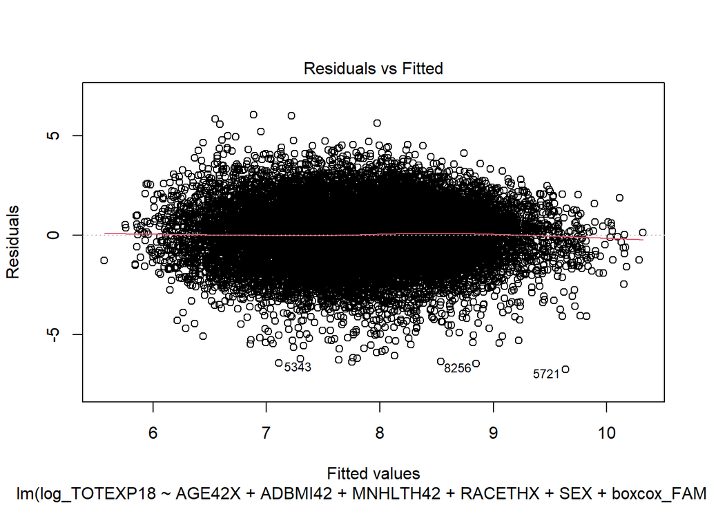

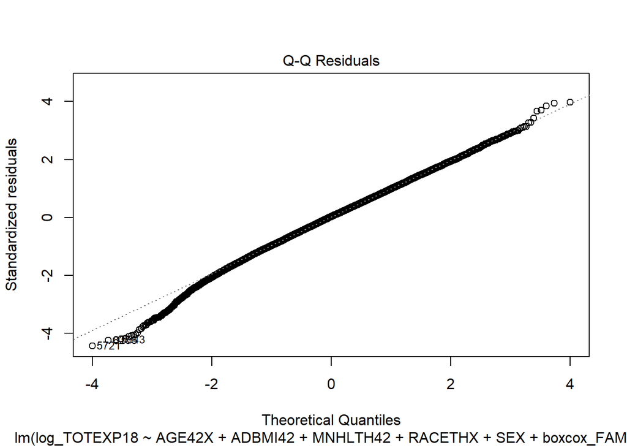

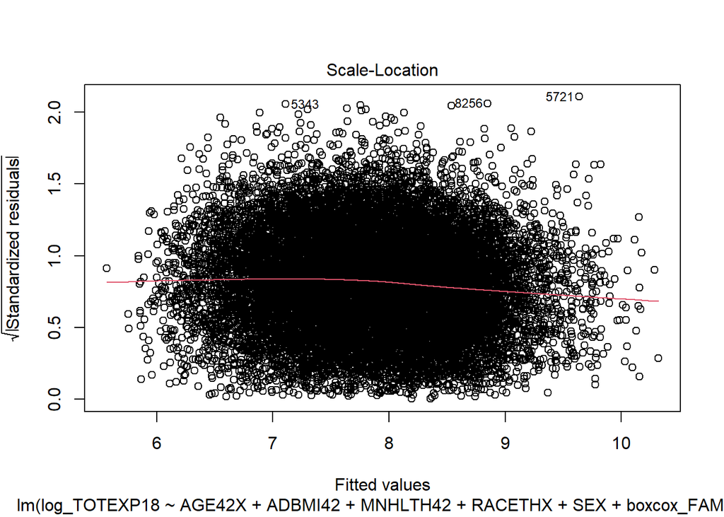

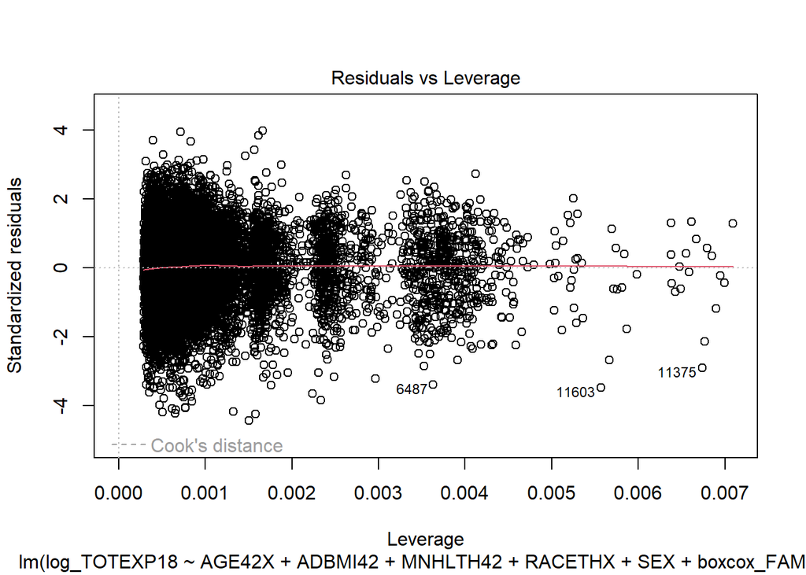

```r
plot(simple_model)
```

```r
# conf intervals
conf_intervals = confint(simple_model, level = 0.95)
print(conf_intervals)
```

```
##                                 2.5 %       97.5 %
## (Intercept)               4.843772354  5.210181466
## AGE42X                    0.029230181  0.031914593
## ADBMI42                   0.017215715  0.024037802
## MNHLTH42FAIR              0.815159298  1.006244823
## MNHLTH42GOOD              0.294128575  0.422344887
## MNHLTH42POOR              1.129804960  1.498218253
## MNHLTH42VERY GOOD         0.048178958  0.168394346
## RACETHXBLACK ONLY         0.113121051  0.372833154
## RACETHXHISPANIC          -0.110573285  0.140465430
## RACETHXOTHER OR MULTIPLE  0.337295623  0.687069788
## RACETHXWHITE ONLY         0.458191984  0.686557096
## SEXMALE                  -0.373150181 -0.276839323
## boxcox_FAMINC18           0.000553698  0.001380761
## NO_INC1                  -0.070511489  0.285088115
```

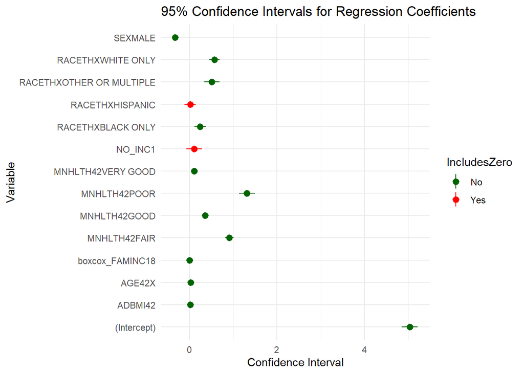

```r
# Convert to data frame for plotting
conf_intervals_df <- as.data.frame(conf_intervals)
conf_intervals_df$Variable <- rownames(conf_intervals_df)  # Add variable names as a column

# Create a new column to indicate if the confidence interval includes 0
conf_intervals_df$IncludesZero <- ifelse(conf_intervals_df$`2.5 %` > 0 | conf_intervals_df$`97.5 %` < 0, "No", "Yes")

# Plot the confidence intervals
ggplot(conf_intervals_df, aes(x = Variable, ymin = `2.5 %`, ymax = `97.5 %`, color = IncludesZero)) +
  geom_pointrange(aes(y = ( `2.5 %` + `97.5 %` ) / 2)) +  # Use midpoint for 'y'
  coord_flip() +  # Flip coordinates to make the plot horizontal
  theme_minimal() +
  labs(
    title = "95% Confidence Intervals for Regression Coefficients",
    x = "Variable",
    y = "Confidence Interval"
  ) +
  scale_color_manual(values = c("Yes" = "red", "No" = "darkgreen"))
```

### Train/test split:

```r
train_size = nrow(data) - 2000
train_data = data[1:train_size, ]
test_data = data[(train_size + 1):nrow(data), ]
```

### Train/test prediction error for simple model:

```r
simple_model_ = lm(log_TOTEXP18 ~ AGE42X + ADBMI42 + MNHLTH42 + RACETHX + SEX + boxcox_FAMINC18 + NO_INC, data=train_data)
simple_model_pred = predict(simple_model_, newdata = test_data)
simple_model_pred = exp(simple_model_pred) - 1 # undo log transformation
simple_model_mse = mean((test_data$TOTEXP18 - simple_model_pred)^2)
print(paste("MSE for simple model = ", simple_model_mse))
```

```
## [1] "MSE for simple model =  337167774.117127"
```

```r
print(paste("RMSE for simple model = ", sqrt(simple_model_mse)))
```

```
## [1] "RMSE for simple model =  18362.1288013434"
```

### Train/test prediction error for full model:

```r
full_model_ = lm(model_formula, data=train_data)
full_model_pred = predict(full_model_, newdata = test_data)
full_model_pred = exp(full_model_pred) - 1 # undo log transformation
full_model_mse = mean((test_data$TOTEXP18 - full_model_pred)^2)
print(paste("MSE for full model = ", full_model_mse))
```

```
## [1] "MSE for full model =  336947320.599903"
```

```r
print(paste("RMSE for full model = ", sqrt(full_model_mse)))
```

```
## [1] "RMSE for full model =  18356.1248797207"
```

### Train/test prediction error for stepwise model:

```r
null_model_ = lm(log_TOTEXP18~1, data=train_data)
stepwise_model_ = step(null_model, scope = list(lower = null_model, upper = full_model_), direction = "both", k = 2, trace = FALSE, test = "F", steps = 1000, add = 0.05 , drop = 0.05)

stepwise_model_pred = predict(stepwise_model_, newdata = test_data)
stepwise_model_pred = exp(stepwise_model_pred) - 1 # undo log transformation
stepwise_model_mse = mean((test_data$TOTEXP18 - stepwise_model_pred)^2)
print(paste("MSE for stepwise model = ", stepwise_model_mse))
```

```
## [1] "MSE for stepwise model =  336966631.013725"
```

```r
print(paste("RMSE for stepwise model = ", sqrt(stepwise_model_mse)))
```

```
## [1] "RMSE for stepwise model =  18356.6508659321"
```

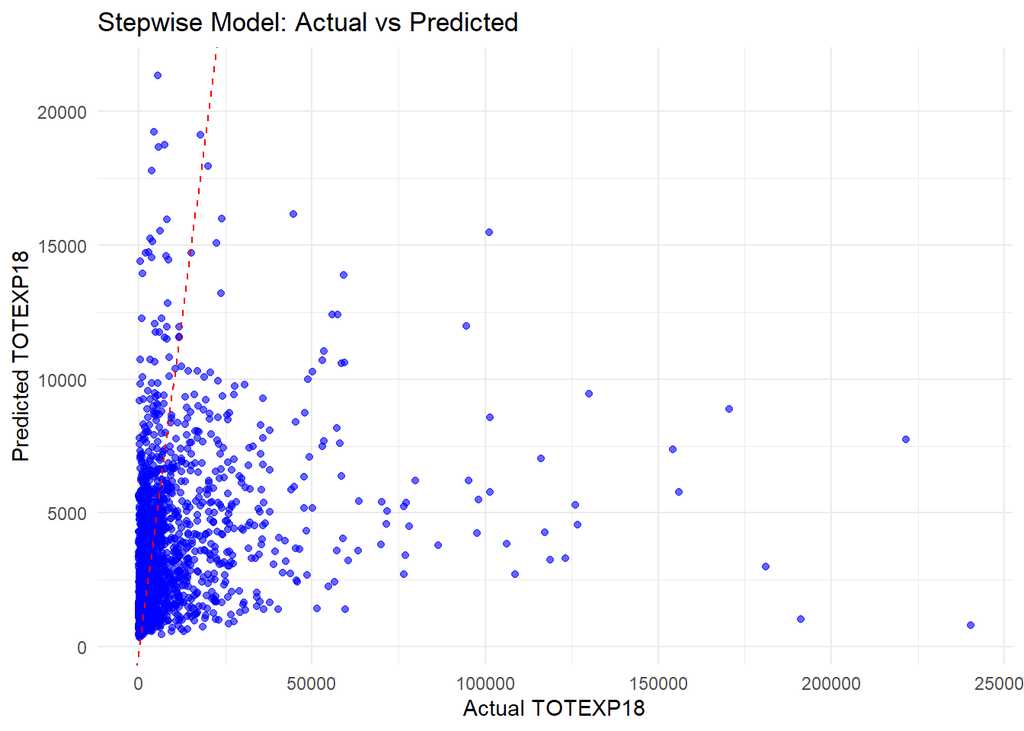

```r
test = test_data
test = cbind(stepwise_model_pred, test)
test$diff = (test$stepwise_model_pred - test$TOTEXP18)^2


# Plot actual vs predicted
plot_data = data.frame(
  Actual = test_data$TOTEXP18,
  Predicted = stepwise_model_pred
)

ggplot(plot_data, aes(x = Actual, y = Predicted)) +
  geom_point(alpha = 0.6, color = 'blue') +  # scatter plot of actual vs predicted
  geom_abline(slope = 1, intercept = 0, color = "red", linetype = "dashed") + # diagonal line for reference
  labs(
    title = "Stepwise Model: Actual vs Predicted",
    x = "Actual TOTEXP18",
    y = "Predicted TOTEXP18"
  ) +
  theme_minimal()
```

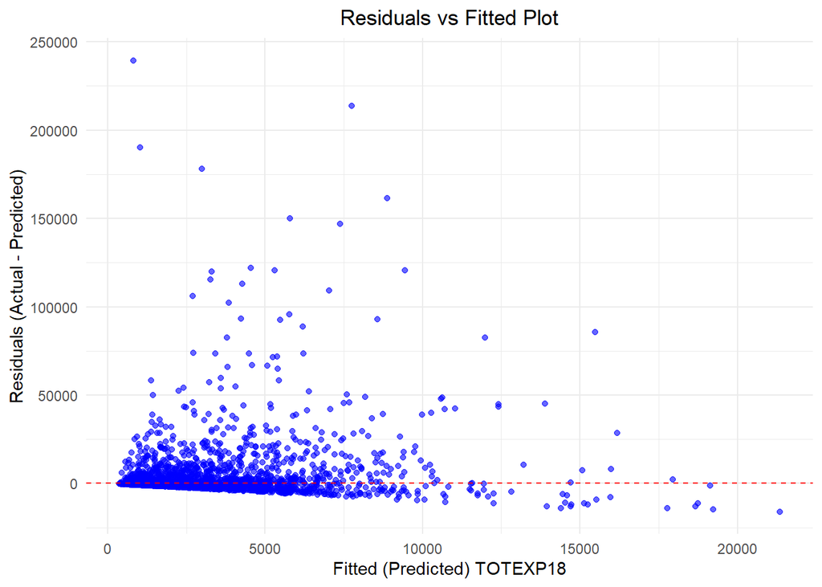

```r
# Plot residuals vs fitted for test data
residuals = test_data$TOTEXP18 - stepwise_model_pred

residuals_data = data.frame(
  Fitted = stepwise_model_pred,  # Predicted values (fitted)
  Residuals = residuals         # Residuals (errors)
)

ggplot(residuals_data, aes(x = Fitted, y = Residuals)) +
  geom_point(alpha = 0.6, color = 'blue') + # Scatter plot of residuals vs fitted
  geom_hline(yintercept = 0, color = "red", linetype = "dashed") + # Horizontal line at 0
  labs(
    title = "Residuals vs Fitted Plot",
    x = "Fitted (Predicted) TOTEXP18",
    y = "Residuals (Actual - Predicted)"
  ) +
  theme_minimal() +
  theme(
    plot.title = element_text(hjust = 0.5)  # Center the title
  )
```

### From the QC plots I made, it looks like a lot of my error comes from under estimating total expenditure for observations with some relatively high expenditures.

### Train/test prediction error for lasso model:

```r
X = model.matrix(model_formula, data = train_data)[, -1]
X_test = model.matrix(model_formula, data = test_data)[, -1]

# lasso model
lasso_ = glmnet(x = X, y = train_data$log_TOTEXP18, alpha = 1)

# cv to find optimal lambda
cv_lasso_ = cv.glmnet(x = X, y = train_data$log_TOTEXP18, alpha = 1, nfolds = 10)
best_lambda_ = cv_lasso_$lambda.min
best_lasso_ = glmnet(x = X, y = train_data$log_TOTEXP18, alpha = 1, lambda = best_lambda_)
coefficients_best_lasso_ = coef(best_lasso_)

# Make predictions using the best_lasso model
best_lasso_pred <- predict(best_lasso_, newx = X_test, s = best_lambda_)

# Inverse transform the predictions (since the target was log-transformed)
best_lasso_pred <- exp(best_lasso_pred) - 1

# Calculate MSE (Mean Squared Error)
best_lasso_mse <- mean((test_data$TOTEXP18 - best_lasso_pred)^2)

# Calculate RMSE (Root Mean Squared Error)
best_lasso_rmse <- sqrt(best_lasso_mse)

# Print the results
print(paste("MSE for Lasso model = ", best_lasso_mse))
```

```
## [1] "MSE for Lasso model =  339513246.296453"
```

```r
print(paste("RMSE for Lasso model = ", best_lasso_rmse))
```

```
## [1] "RMSE for Lasso model =  18425.8852242288"
```

### So it looks like all 4 models I fit don’t perform amazingly well. RMSE error is about $18,000 for all models. Lowest error is full model, then stepwise model, then simple model, then lasso model. This doesn’t totally make sense to me because the full model should be more prone to overfitting. But I’ve already spent 10hrs on this and I have other classes.

## Problem 5:

### I found that mental health was a good indicator of how total medical expenditure. People with poor mental health spend the most, followed by those with fair, followed by those with good, then very good.

### I found that older people have higher total expenditure.

### I found that the “black only” ethnicity had higher expenditure. “Hispanic” also had higher expenditure but not as high as “black only”.

### I found that people with no income have less expenditure.

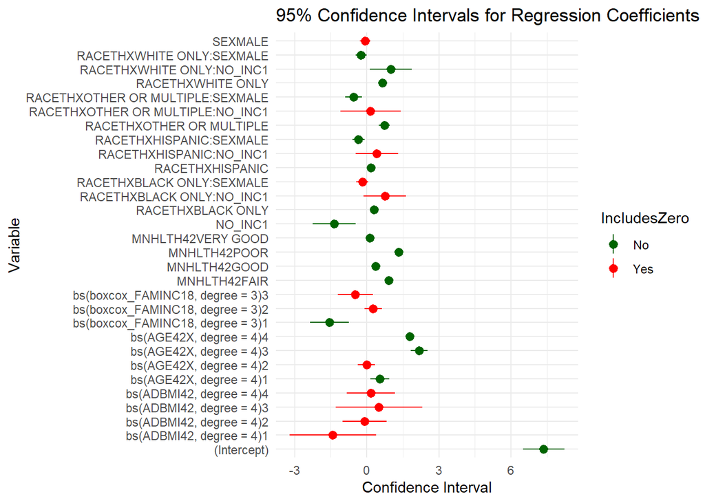

```r
conf_intervals = confint(stepwise, level = 0.95)

# Convert to data frame for plotting
conf_intervals_df <- as.data.frame(conf_intervals)
conf_intervals_df$Variable <- rownames(conf_intervals_df)  # Add variable names as a column

# Create a new column to indicate if the confidence interval includes 0
conf_intervals_df$IncludesZero <- ifelse(conf_intervals_df$`2.5 %` > 0 | conf_intervals_df$`97.5 %` < 0, "No", "Yes")

# Plot the confidence intervals
ggplot(conf_intervals_df, aes(x = Variable, ymin = `2.5 %`, ymax = `97.5 %`, color = IncludesZero)) +
  geom_pointrange(aes(y = ( `2.5 %` + `97.5 %` ) / 2)) +  # Use midpoint for 'y'
  coord_flip() +  # Flip coordinates to make the plot horizontal
  theme_minimal() +
  labs(
    title = "95% Confidence Intervals for Regression Coefficients",
    x = "Variable",
    y = "Confidence Interval"
  ) +
  scale_color_manual(values = c("Yes" = "red", "No" = "darkgreen"))
```

### The paper “Racial and Ethnic Disparities in Health Care Use and Expenditures: Evidence from the MEPS” by R. E. Schoen, B. M. Stokes, & A. P. Ko (Health Affairs, 2013) also found that black and hispanic populations had higher total expenditure.

### The paper “The Relationship Between Age and Health Care Expenditures in the United States” by H. A. Skinner, J. M. Staiger, & E. F. P. Rosenthal (The Journal of Health Economics, 2010) found that healthcare expenditure increases with age.

### These support my findings.